# Model checking as model *building*: length of stay in the RHC/SUPPORT study

An in-class walkthrough for the Linear Regression II chapter

## Support study

- SUPPORT trial 1989-1994 tested an intervention to improve end-of-life decision making and reduce mechanically supported, painful, and prolonged process of dying.
- Intervention: Physicians and their seriously ill admitted patients were randomized at the physician level to receiving daily estimates of 6 month survival for each patient and nursing support to work on a) eliciting preferences, b) helping family understand predicted outcomes, c) facilitate advanced plannng and d) communication.
- Design: 2-year prospective observational study (phase I - 4301 patients) then a 2-year clinical trial (phase II) that randomized clinical services or specialty groups with their patients (2652-intervention, 2152 control). (A cluster was defined as a distinct clinical service or subspecialty group at a hospital, e.g. all the attending physicians and residents assigned to the Cardiology Service, General Internal Medicine Team A, or the Pulmonary/Critical Care Service)

### Support/RHC Study

- Emebeded within Support Trial (Connors et al., 1996)
- MotivationLevaluate the clinical effectiveness of Right Heart Catheterization (RHC)—also known as a Swan-Ganz catheter—in the initial 24 hours of adult care in the intensive care unit (ICU).
- RHC was widely used but with little evidence supporting use
- (enough) Clinicians strong belief in the benfit precluded RCT.
- Design: Prospective cohort study. N=5734 patients from the parent SUPPORT study
- Inclusion:
  - admitted to the ICU in the first 24 hours
  - fit one of 9 pre-specified diagnostic categories
  - complete covariate data recorded in the first 24 hours.

Load the data (`load_data`)

## 1. Model of predictors of length of stay (LOS)

**Question**

We want to describe how hospital length of stay varies across ICU patients.

- One of the advantages of SUPPORT was the comprehensive severity of illness data summarized in the 2 and 6 month survival prediction.
- Knaus (the APACHE developer) was an investigator and the acute physiology score on day 1 is part of the prediction model.

Fit a model on disease category, day-1 predicted survival, age, and sex (`round1`):

```stata
use rhc_class_tph.dta, clear
generate los = dschdte - sadmdte
drop if missing(los) | los <= 0
regress los i.cat1 c.surv2md1 c.age i.sex
```

**Are we done?**

**Hint**

**Try simulating an outcome from the fitted model and compare to the data.**

A normal-error model spreads predictions *symmetrically* around the mean.

**Answer**

```stata
regress los i.cat1 c.surv2md1 c.age i.sex
set seed 20260912
qui predict double xb_naive
generate double los_sim = xb_naive + rnormal(0, e(rmse))
count if los_sim < 0
twoway (kdensity los, lcolor(navy) lwidth(thick)) ///
       (kdensity los_sim, lcolor(cranberry) lwidth(thick)), ///
       xline(0, lpattern(dash) lcolor(red)) ///
       legend(order(1 "Observed LOS" 2 "Simulated from model") ring(0) pos(2)) ///
       xtitle("Length of stay (days)") ///
       title("The model invents impossible negative stays")
qui graph export img/rhc_naive_sim.png, replace width(1400)
```

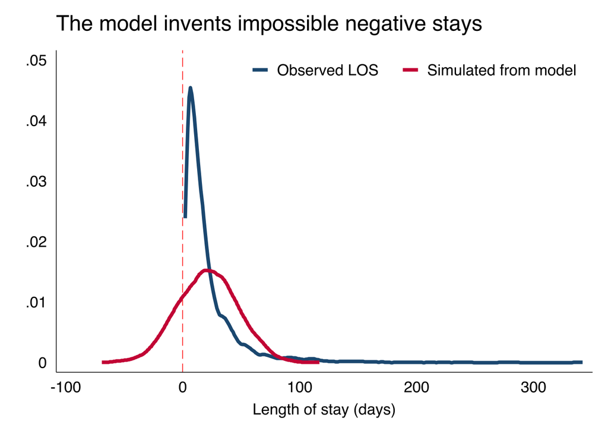

Observed length of stay versus a dataset simulated from the naive model. The simulated distribution is symmetric and pushes a large mass below zero (dashed red line), which is impossible for a length of stay.

## 2. What does the outcome look like overall and across predictors?

**Question**

Think about functional form and **graph the data**.

1. What does LOS look like **raw vs. logged**?
2. How does it differ across **primary disease category**?
3. How does it differ by **DNR status** and by **in-hospital death**?
4. How does it change across a **severity range** (day-1 predicted survival)?

**Hint**

- `histogram` of `los` and of `ln(los)` — is either roughly symmetric?
- `graph hbox` over `cat1` — do the differences make sense?
- `kdensity` by `dnr1` and by `diedhosp` — does LOS mix distinct groups?
- `lowess` of LOS on `surv2md1`, pooled and then split by `diedhosp` — is the pooled shape a single trend or a **mixture**?

**Answer-1**

**Raw vs. log.** The raw outcome is heavily right-skewed with a floor at zero; the log scale is roughly symmetric. (`raw_vs_log`)

```stata
histogram los, width(10) fcolor(midblue%40) lcolor(white) ///
    xtitle("Length of stay (days)") title("Raw LOS: heavy right skew") ///
    name(d1, replace)
histogram lnlos, fcolor(midblue%40) lcolor(white) ///
    xtitle("log length of stay") title("log LOS: roughly symmetric") ///
    name(d2, replace)
graph combine d1 d2, rows(1)
qui graph export img/rhc_dist.png, replace width(1600)
```

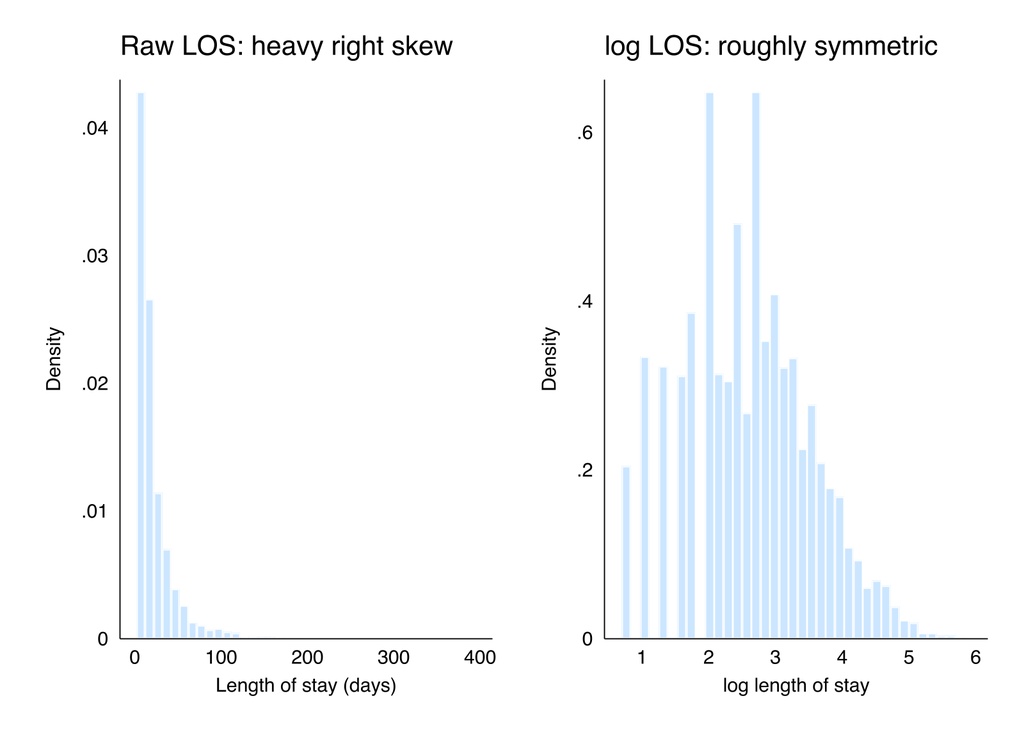

Histograms of raw and log length of stay. Raw LOS is strongly right-skewed with a floor at zero; log LOS is close to symmetric.

**Answer-2**

**By disease category.** Sepsis and acute respiratory failure longer; CHF and the cancer shorter. Disease category clearly belongs in the model. (`by_disease`)

```stata
graph hbox los, over(cat1, sort(1)) nooutside ///
    title("LOS varies a lot by disease category")
qui graph export img/rhc_cat.png, replace width(1400)
table cat1, statistic(count los) statistic(median los) statistic(mean los)
```

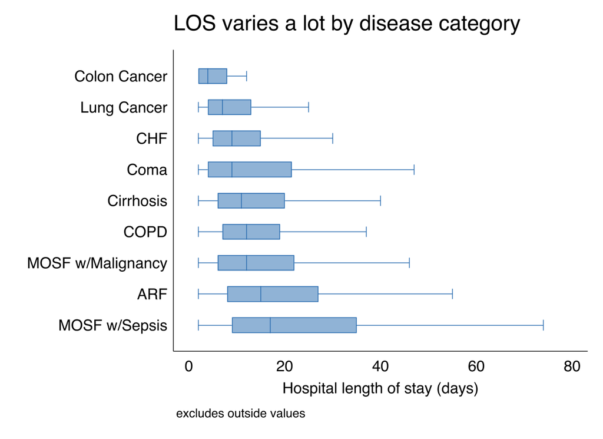

Horizontal box plots of LOS by primary disease category, sorted by median. Sepsis and acute respiratory failure have the longest stays; congestive heart failure and cancers the shortest.

Some of the *short*-stay diagnoses are puzzling — hold that thought for section 3.

**Answer-3**

**By disposition and DNR.** LOS mixes distinct care trajectories: patients who die in hospital and patients made DNR on day 1 have markedly shorter stays. (`by_dnr_died`)

```stata
twoway (kdensity los if diedhosp==0, lcolor(navy)) ///
       (kdensity los if diedhosp==1, lcolor(cranberry)), ///
       legend(order(1 "Discharged alive" 2 "Died in hospital") ring(0) pos(2)) ///
       xtitle("length of stay") title("LOS mixes survivors and deaths") ///
       name(g1, replace)
twoway (kdensity los if dnr1==0, lcolor(navy)) ///
       (kdensity los if dnr1==1, lcolor(cranberry)), ///
       legend(order(1 "Not DNR" 2 "DNR day 1") ring(0) pos(2)) ///
       xtitle("length of stay") title("Shorter stays under day-1 DNR") ///
       name(g2, replace)
graph combine g1 g2, rows(1)
qui graph export img/rhc_groups.png, replace width(1600)
```

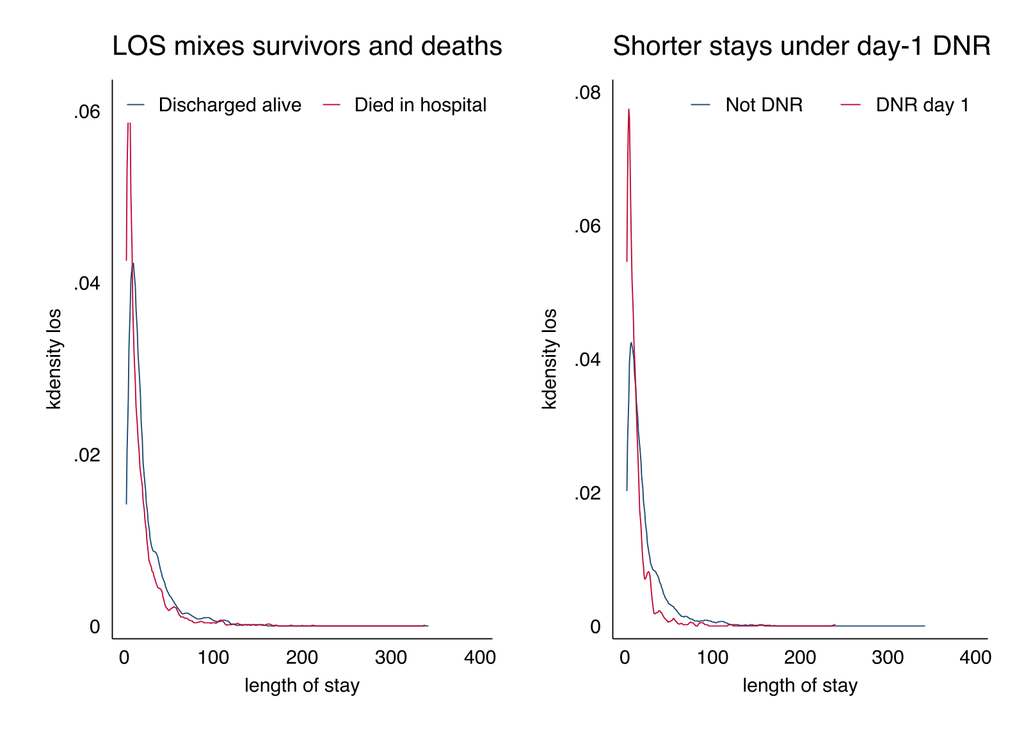

Kernel densities of LOS by in-hospital death and by day-1 DNR status. Patients who die in hospital, and patients made DNR, have shorter stays.

**Answer-4**

**Across the severity range — the key graph.** Pooled, LOS traces an **inverted-U** in predicted survival. Split by disposition, it is **two opposite trends**: among survivors, sicker patients stay longer; among those who die, the predicted-to-survive linger longest. The pooled curve is a **mixture**. (`across_sev`)

```stata
twoway (lowess los surv2md1, lcolor(black) lwidth(thick) lpattern(dash)) ///
       (lowess los surv2md1 if diedhosp==0, lcolor(navy) lwidth(thick)) ///
       (lowess los surv2md1 if diedhosp==1, lcolor(cranberry) lwidth(thick)), ///
       legend(order(1 "All patients (pooled)" 2 "Discharged alive" ///
                    3 "Died in hospital") ring(0) pos(1) cols(1)) ///
       xtitle("Predicted 2-month survival at day 1") ytitle("LOS (days)") ///
       title("The pooled inverted-U is a mixture of two opposite trends")
qui graph export img/rhc_mix.png, replace width(1500)
```

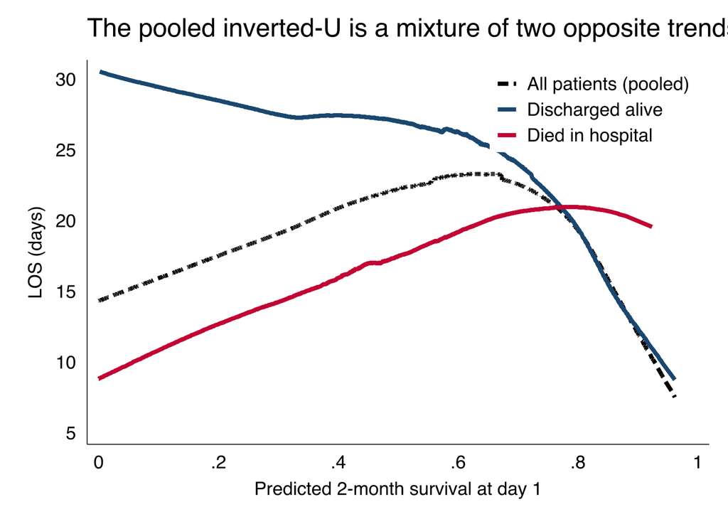

Lowess curves of LOS against day-1 predicted survival: the pooled curve is an inverted-U, while the curves split by in-hospital death run in opposite directions, showing the pooled shape is a mixture.

**take-home**

**What did we learn:**

1. describe LOS on the **log scale**;
2. include **disease category** and **DNR**
3. allow **curvature** across the predicted-survival range;
4. LOS **mixes** survivors and in-hospital deaths, whose severity patterns run in opposite directions
5. DNR may account for some of this in the multivariable model;
6. DNR may explain some of the odd short-stay diagnosis specific LOS.

## 3. A descriptive model and predictive comparisons

**Question**

Build the models the graphs suggested:

1. log outcome, disease category, a curve in predicted survival, and DNR

Because the outcome is logged, how do we talk about **days**? We want to report predicted **mean** LOS across disease category, DNR, the survival range, and age. (see Hint)

2. Display Predicted mean LOS by disease category (case-mix held fixed)
3. Does DNR explain the odd short-stay diagnoses?
4. Predicted mean LOS by DNR status and across the survival range
5. Predicted mean LOS across age

**Hint**

**Duan’s (1983) smearing factor** Used famously in the Rand Health Insurance Experiment

- If in prediction you just use `exp(xb)` - it back-transforms the log LOS to the **median**, not the mean, because averaging happened on the log scale.
- The Duan smearing factor: `scalar duan = mean(exp(residual))`, rescales predictions to the mean.
- You can include it in the `margins` command to get predictions in days: `margins cat1, expression(duan*exp(xb()))`.

**Answer-1**

Fit the new model and build the Duan factor (`round2`):

```stata
regress lnlos i.cat1 c.surv2md1##c.surv2md1 i.dnr1 c.age i.sex
capture drop e_resid e_expresid
predict double e_resid, residuals
generate double e_expresid = exp(e_resid)
summarize e_expresid, meanonly
scalar duan = r(mean)
display "Duan smearing factor = " duan
```

```
      Source |       SS           df       MS      Number of obs   =     5,734
-------------+----------------------------------   F(13, 5720)     =     52.58
       Model |  526.770235        13  40.5207873   Prob > F        =    0.0000
    Residual |  4408.35412     5,720  .770691281   R-squared       =    0.1067
-------------+----------------------------------   Adj R-squared   =    0.1047
       Total |  4935.12436     5,733  .860827553   Root MSE        =    .87789

------------------------------------------------------------------------------
       lnlos | Coefficient  Std. err.      t    P>|t|     [95% conf. interval]
-------------+----------------------------------------------------------------
        cat1 |
       COPD  |   -.088921   .0476177    -1.87   0.062    -.1822698    .0044277
        CHF  |  -.3817475   .0504267    -7.57   0.000     -.480603    -.282892
  Cirrhosis  |  -.3559041   .0619406    -5.75   0.000    -.4773312   -.2344769
       Coma  |  -.3182326   .0497025    -6.40   0.000    -.4156683   -.2207969
Colon Can..  |  -.9543939   .3326949    -2.87   0.004    -1.606602   -.3021859
Lung Cancer  |  -.6934464   .1420365    -4.88   0.000    -.9718917    -.415001
MOSF w/Ma..  |  -.2312203   .0525082    -4.40   0.000    -.3341564   -.1282843
MOSF w/Se..  |   .0936345   .0310011     3.02   0.003     .0328607    .1544084
    surv2md1 |   2.490354   .2922667     8.52   0.000     1.917401    3.063308
  c.surv2md1#|
  c.surv2md1 |  -2.456119   .2864605    -8.57   0.000     -3.01769   -1.894548
        dnr1 |
        yes  |  -.5876548   .0379104   -15.50   0.000    -.6619735   -.5133362
         age |  -.0031058   .0008242    -3.77   0.000    -.0047216     -.00149
         sex |
       Male  |   -.031679   .0234989    -1.35   0.178    -.0777457    .0143877
       _cons |   2.456691   .0925653    26.54   0.000     2.275228    2.638154
------------------------------------------------------------------------------






Duan smearing factor = 1.4946346
```

**Answer-2**

**Predicted mean LOS by disease category** (case-mix held fixed `pr_by_dz`):

```stata
margins cat1, expression(duan*exp(xb()))
marginsplot, horizontal recast(scatter) ///
    title("Predicted mean LOS by disease category") ///
    xtitle("Predicted LOS (days)")
qui graph export img/rhc_pc_cat.png, replace width(1400)
```

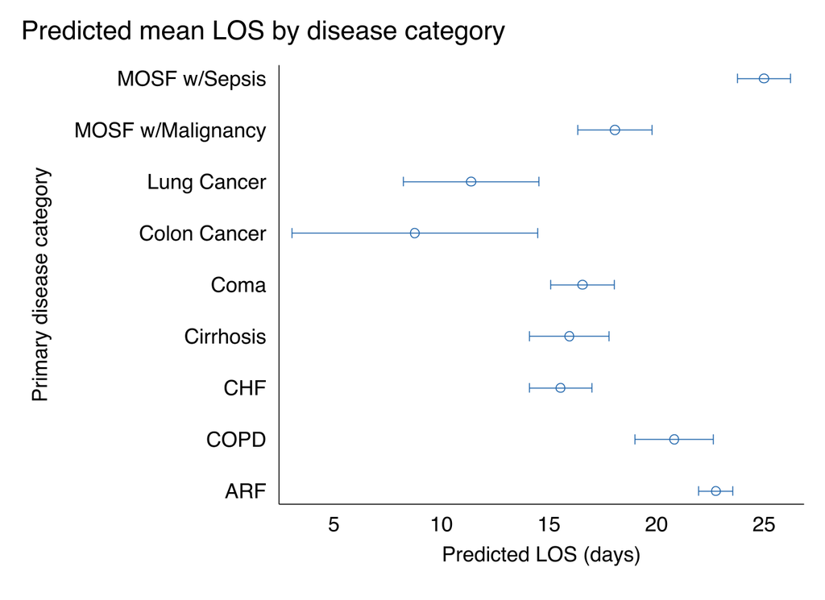

Predicted mean length of stay by disease category, back-transformed to days with the Duan factor.

**Answer-3**

**Does DNR explain the odd short-stay diagnoses?** Let DNR interact with disease category. (`dnr_by_dz`)

```stata
quietly regress lnlos i.cat1##i.dnr1 c.surv2md1##c.surv2md1 c.age i.sex
testparm i.cat1#i.dnr1
estimates store m_interact
quietly regress lnlos i.cat1 c.surv2md1##c.surv2md1 i.dnr1 c.age i.sex
estimates store m_additive
estimates stats m_additive m_interact
```

```
 ( 1)  2.cat1#1.dnr1 = 0
 ( 2)  3.cat1#1.dnr1 = 0
 ( 3)  4.cat1#1.dnr1 = 0
 ( 4)  5.cat1#1.dnr1 = 0
 ( 5)  6.cat1#1.dnr1 = 0
 ( 6)  7.cat1#1.dnr1 = 0
 ( 7)  8.cat1#1.dnr1 = 0
 ( 8)  9.cat1#1.dnr1 = 0

       F(  8,  5712) =    2.91
            Prob > F =    0.0031





Akaike's information criterion and Bayesian information criterion

-----------------------------------------------------------------------------
       Model |          N   ll(null)  ll(model)      df        AIC        BIC
-------------+---------------------------------------------------------------
  m_additive |      5,734  -7706.042  -7382.425      14   14792.85   14886.01
  m_interact |      5,734  -7706.042  -7370.771      22   14785.54   14931.93
-----------------------------------------------------------------------------
Note: BIC uses N = number of observations. See [R] IC note.
```

```stata
qui margins cat1#dnr1, expression(duan*exp(xb()))
marginsplot, recast(scatter) xlabel(, angle(45))
qui graph export img/dnr_by_dz.png, replace width(1400)
```

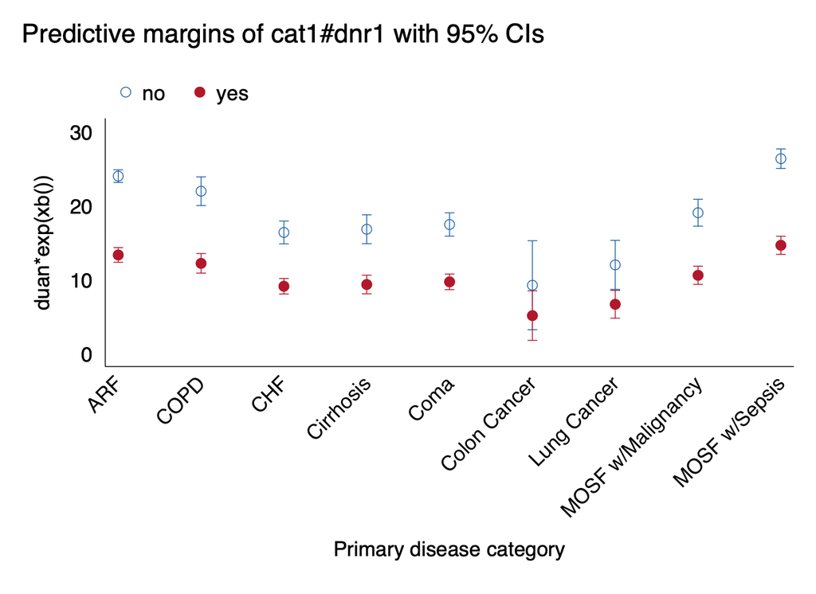

Predicted mean length of stay by disease category and DNR, back-transformed to days with the Duan factor.

**Answer-4**

**Predicted mean LOS by DNR status** and **across the survival range**: (`pr_dnr_surv`)

```stata
margins dnr1, expression(duan*exp(xb()))
marginsplot, recast(scatter) ///
    title("Predicted mean LOS: DNR vs not") ytitle("Predicted LOS (days)")
qui graph export img/rhc_pc_dnr.png, replace width(1300)
```

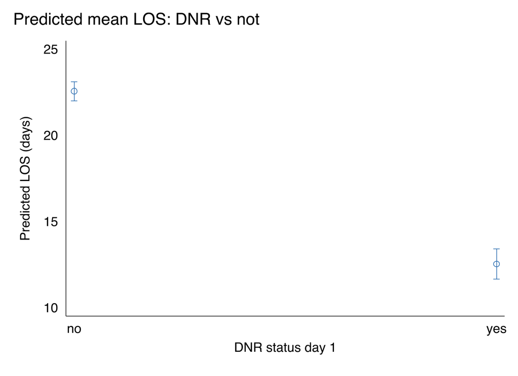

Predicted mean LOS for DNR versus non-DNR patients.

```stata
margins, at(surv2md1=(0.1(0.05)0.9)) expression(duan*exp(xb()))
marginsplot, recast(line) recastci(rarea) ciopts(color(%20)) ///
    title("Predicted mean LOS across the severity range (an inverted-U)") ///
    ytitle("Predicted LOS (days)") xtitle("Predicted 2-month survival")
qui graph export img/rhc_pc_surv.png, replace width(1400)
```

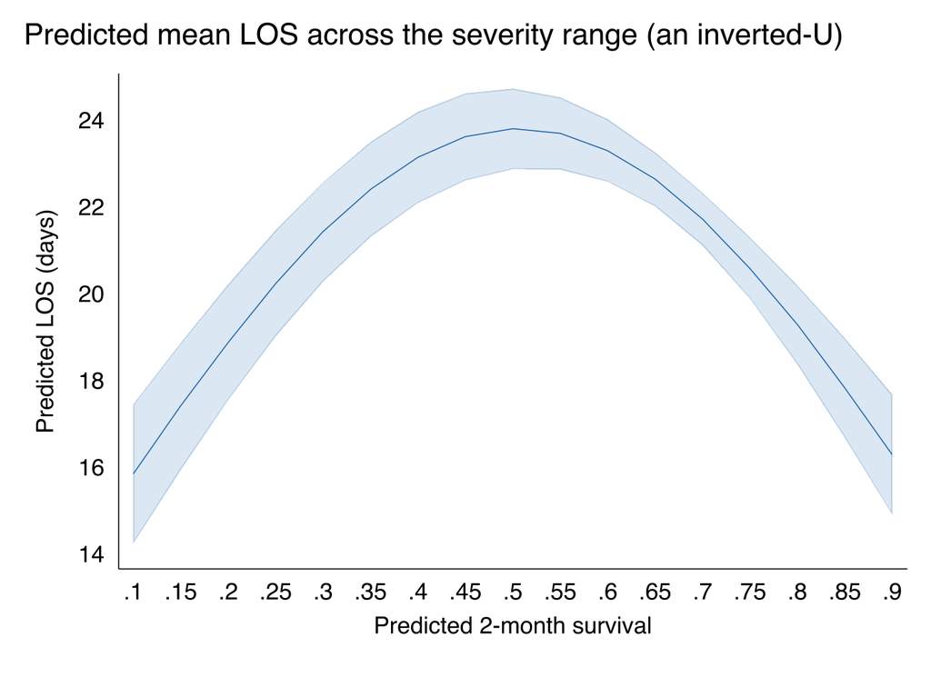

Predicted mean LOS across the day-1 predicted-survival range, showing an inverted-U.

**Answer-5**

**Predicted mean LOS across age:** (`pr_los_age`)

```stata
margins, at(age=(30(10)90)) expression(duan*exp(xb()))
marginsplot, recast(line) recastci(rarea) ciopts(color(%20)) ///
    title("Predicted mean LOS across age") ytitle("Predicted LOS (days)")
qui graph export img/rhc_pc_age.png, replace width(1400)
```

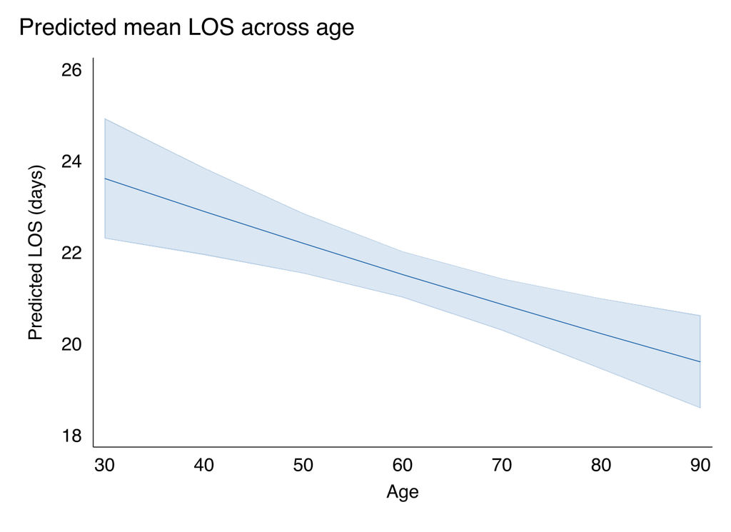

Predicted mean LOS across age.

These are **predictive comparisons** — expected stay for patients who share these characteristics, case-mix held fixed — **not** causal effects of the disease, age, or DNR order itself.

## 4. The inverted-U is a mixture and a caution about colliders

**Question**

The survival-range prediction (answer A-4 above) again showed the **inverted-U**, this time while holding other variables constant: expected stay rises, then falls, as day-1 predicted survival increases. It is obvious to most clinicians why the sickest and the healthiest patients have shorter stays.

1. Show the different survival curves by whether the patient lived or died in the hospital
2. Given the findings should we simply **adjust** for in-hospital death to describe the curves better?

**Hint**

Split the curve by whether the patient **died in hospital**. Then think carefully about *when* death is measured relative to the day-1 predictors.

**Answer**

Run `surv_by_dispo`

```stata
quietly regress lnlos c.surv2md1##c.surv2md1##i.diedhosp
margins diedhosp, at(surv2md1=(0.1(0.05)0.9)) expression(exp(xb()))
marginsplot, recast(line) ///
    title("Two trajectories: survivors vs in-hospital deaths") ///
    ytitle("Predicted median LOS (days)") xtitle("Predicted 2-month survival")
qui graph export img/rhc_pc_split.png, replace width(1400)
```

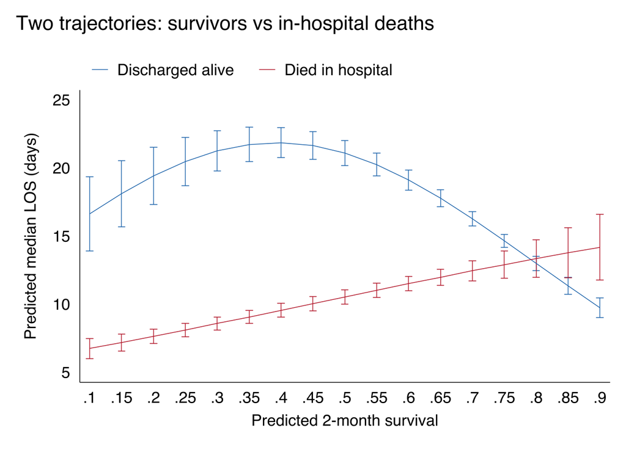

Predicted LOS across the survival range, split by in-hospital death: survivors and deaths run in opposite directions, explaining the pooled inverted-U.

Whether someone lived or died is an event that occurs *after* the baseline and so if you were to condition on it, it would be a *collider*. It can introduce spurious associations between variables when you are trying to describe the predictive comparisons between groups.

- **Descriptive** goal → allow the flexibility in the baseline predictor above to describe each group.
- **Causal / explanatory** goal → treat death as a **competing event** (cause-specific or Fine–Gray), or use a **multi-state** or **joint** (longitudinal–survival) model.

Take-home: you cannot adjust your way out of a downstream-variable collider by adding it to a regression. Selecting a study population based on a collider functions exactly the same way as trying to adjust for it in the regression.

## 5. Do the predictions look like the data? Overall fit

**Question**

Now check the model as a whole.

1. Simulate replication datasets from the fitted model and compare them to the observed data
2. Check pointwise calibration with the **PIT** and with **50% / 90% interval coverage**.
3. Contrast the naive **raw-days** model with the **log** model.

**Hint**

- Replications: `xb + rnormal(0, e(rmse))`, overlaid `kdensity` vs. observed.
- **PIT**: Transform the residuals into how many standard deviations they are from the predicted mean and then calculate the probability using the cumulative distribution: `normal((y - xb)/rmse)`. These probabilities should have a uniform, e.g **flat**, distribution if the pointwise predictive distributions are calibrated.
- **Coverage**: the fraction of observations inside `xb ± invnormal(p)*rmse` should match the nominal 50% / 90% based on how many standard deviations of the error term they are from the predicdtion.

Note: PIT stands for the ugly sounding “probability integral transformation” but just means that you transform the observed data point to the cumulative probability given the conditional mean and standard distribution.

**Answer-1**

**Raw-days model** — replications invent negative stays, the PIT is not flat, and the intervals over-cover (`p5a1_raw_days`):

```stata
quietly regress los i.cat1 c.surv2md1##c.surv2md1 i.dnr1 c.age i.sex
predict xb_raw, xb
local rmse_raw = e(rmse)
set seed 20260912
local call ""
forvalues i = 1/20 {
    quietly generate los_rep`i' = xb_raw + rnormal(0, `rmse_raw')
    local call `call' (kdensity los_rep`i', lcolor(gs13) lwidth(vthin))
}
twoway `call' (kdensity los, lcolor(navy) lwidth(thick)), legend(off) ///
    xline(0, lpattern(dash) lcolor(red)) xtitle("Length of stay (days)") ///
    title("Raw-days model: replications invent negative stays")
qui graph export img/rhc_ppc_raw.png, replace width(1400)

generate pit_raw = normal((los - xb_raw)/`rmse_raw')
foreach lev in 50 90 {
    local lo = (100 - `lev')/200
    local hi = 1 - `lo'
    quietly count if inrange(los, xb_raw + invnormal(`lo')*`rmse_raw', ///
                                  xb_raw + invnormal(`hi')*`rmse_raw')
    display "RAW coverage of central " `lev' "% = " %4.1f 100*r(N)/_N "% (nominal " `lev' "%)"
}
histogram pit_raw, width(0.05) percent fcolor(midblue%50) lcolor(white) ///
    yline(5, lpattern(dash) lcolor(red)) xtitle("PIT value") ///
    title("Raw model: PIT not flat -> miscalibrated")
qui graph export img/rhc_pit_raw.png, replace width(1300)
```

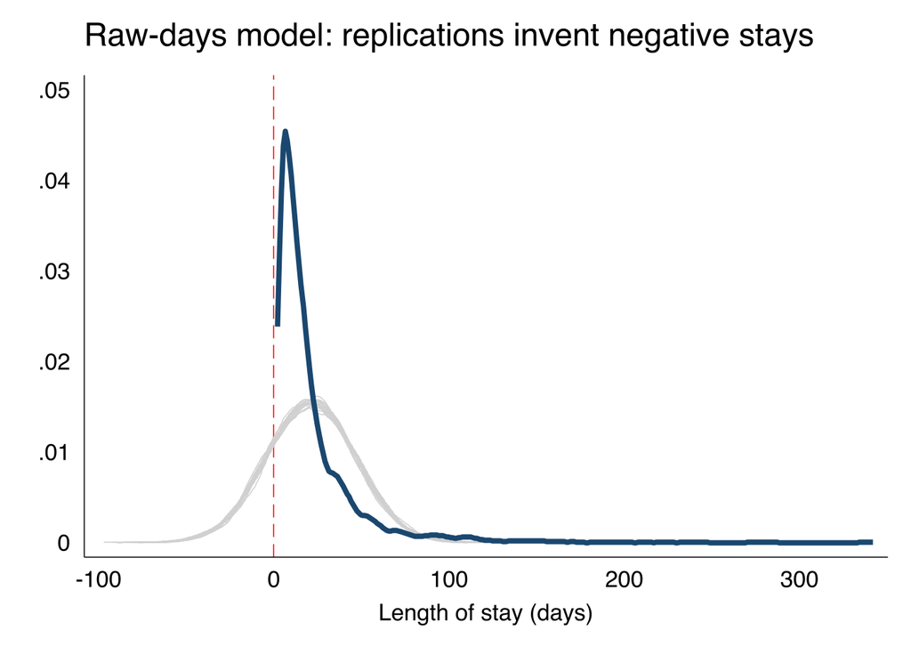

Twenty replication densities from the raw-days model overlaid on the observed LOS; the replications spread below zero.

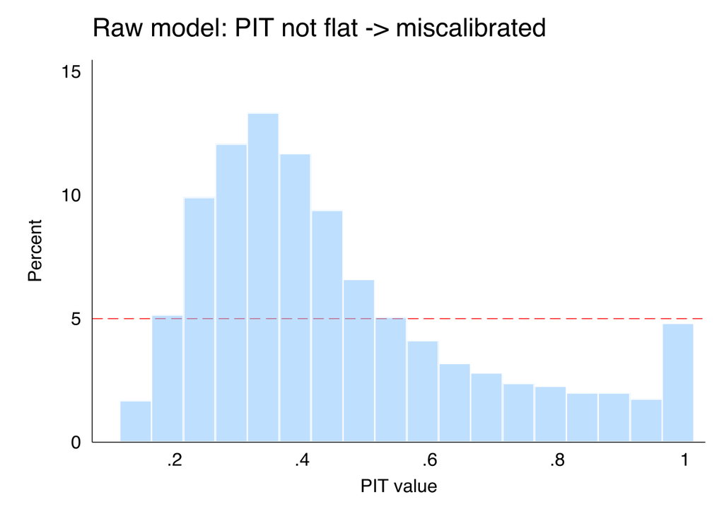

PIT histogram for the raw-days model: far from flat, indicating miscalibration.

**Answer-2**

**Log model** — replications track the data, the PIT is much flatter, and coverage lands near nominal (`p5a2_lnlos_days`):

```stata
quietly regress lnlos i.cat1 c.surv2md1##c.surv2md1 i.dnr1 c.age i.sex
predict xb_log, xb
local rmse_log = e(rmse)
set seed 20260912
local call ""
forvalues i = 1/20 {
    quietly generate lnlos_rep`i' = xb_log + rnormal(0, `rmse_log')
    local call `call' (kdensity lnlos_rep`i', lcolor(gs13) lwidth(vthin))
}
twoway `call' (kdensity lnlos, lcolor(navy) lwidth(thick)), legend(off) ///
    xtitle("log length of stay") title("log model: replications track the data")
qui graph export img/rhc_ppc_log.png, replace width(1400)

generate pit_log = normal((lnlos - xb_log)/`rmse_log')
foreach lev in 50 90 {
    local lo = (100 - `lev')/200
    local hi = 1 - `lo'
    quietly count if inrange(lnlos, xb_log + invnormal(`lo')*`rmse_log', ///
                                    xb_log + invnormal(`hi')*`rmse_log')
    display "LOG coverage of central " `lev' "% = " %4.1f 100*r(N)/_N "% (nominal " `lev' "%)"
}
histogram pit_log, width(0.05) percent fcolor(midblue%50) lcolor(white) ///
    yline(5, lpattern(dash) lcolor(red)) xtitle("PIT value") ///
    title("log model: PIT much flatter -> calibrated")
qui graph export img/rhc_pit_log.png, replace width(1300)
```

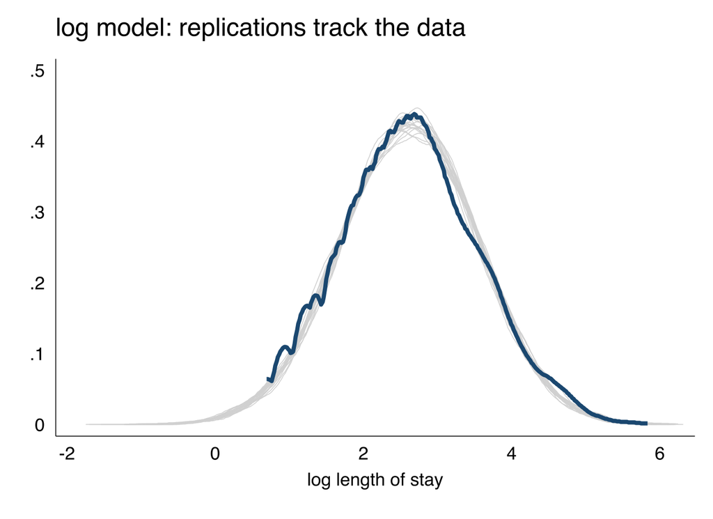

Twenty replication densities from the log model overlaid on observed log LOS; the replications track the data closely.

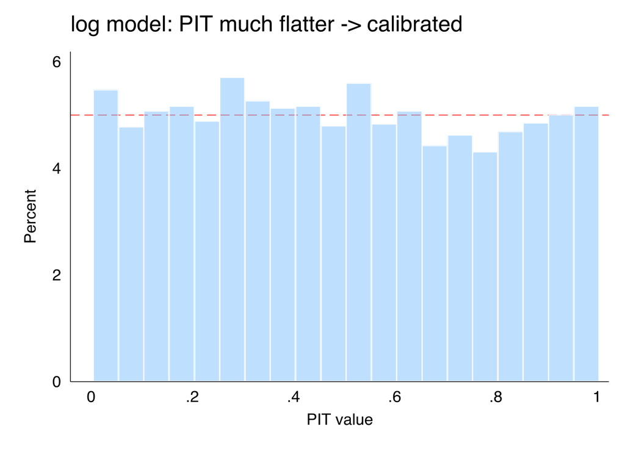

PIT histogram for the log model: much closer to flat.

A caveat for this cacluation of the PIT: `normal((y - xb)/rmse)` treats the fitted mean `xb` and the scale `rmse` as the *true* parameters, so it is only **asymptotically** Uniform(0,1). It ignores that `xb` was fit to `y` itself and that σ was estimated. The exact finite-sample version can be obtained using a Student-t distribution via the jacknife (deleted) residual — see the optional tab.

**Answer-3**

**Model-comparison.** Coverage being a probability, is comparable across the raw and log scales (unlike AIC, which is not comparable across a transformed outcome) (`p5a3_model_comp`):

```stata
quietly regress los i.cat1 c.surv2md1##c.surv2md1 i.dnr1 c.age i.sex
quietly predict double xbr, xb
local rr = e(rmse)
quietly count if xbr < 0
scalar neg_raw = r(N)
qui foreach lev in 50 90 {
    local lo = (100 - `lev')/200
    local hi = 1 - `lo'
    quietly count if inrange(los, xbr + invnormal(`lo')*`rr', xbr + invnormal(`hi')*`rr')
    scalar cov`lev'_raw = 100*r(N)/_N
}
quietly regress lnlos i.cat1 c.surv2md1##c.surv2md1 i.dnr1 c.age i.sex
quietly predict double xbl, xb
local rl = e(rmse)
qui foreach lev in 50 90 {
    local lo = (100 - `lev')/200
    local hi = 1 - `lo'
    quietly count if inrange(lnlos, xbl + invnormal(`lo')*`rl', xbl + invnormal(`hi')*`rl')
    scalar cov`lev'_log = 100*r(N)/_N
}
display "                              naive RAW-days      final LOG model"
display "impossible (<0) predictions  " %8.0f neg_raw  "            " %8.0f 0
display "50% interval coverage        " %7.1f cov50_raw "%           " %7.1f cov50_log "%"
display "90% interval coverage        " %7.1f cov90_raw "%           " %7.1f cov90_log "%"
```

```
                              naive RAW-days      final LOG model

impossible (<0) predictions         5                   0

50% interval coverage           73.0%              50.9%

90% interval coverage           94.7%              89.2%
```

On the log scale the simulated datasets resemble the real data and the pointwise intervals cover near their nominal rates unlike the raw-days model.

**Optional**

**Exact PIT (parameter uncertainty)**

The plug-in PIT above is only asymptotically uniform. The problem is that patient i’s own data helped fit the line, so the line is pulled toward the observed $y_i$, which means the residual is artificially small, especially for unusual patients. This can result in underdispersed residuals and a PIT graph that instead of being flat is bumped up in the middle.

Under a correctly specified normal linear model the **exactly** uniform quantity is found using the *externally studentized (deleted) residual*

$$t_i=\frac{e_i}{s_{(i)}\sqrt{1-h_{ii}}}\sim t_{\,n-p-1},\qquad u_i=T_{n-p-1}(t_i)\sim\text{Uniform}(0,1).$$

That $t_i$ is the standardized **leave-one-out** prediction error ($y_i-\hat y_{i(i)}=e_i/(1-h_{ii})$, with LOO (leave out one) variance $s_{(i)}^2/(1-h_{ii})$). In common language this quantifies how surprising is this specific patient’s stay, in standard deviations, compared to a prediction and an error spread *both computed without this patient’s observation*.

This form of the PIT is the frequentist predictive distribution that includes **parameter uncertainty** — the exact analog of the Bayesian posterior-predictive PIT. In Stata it is obtained using: `predict t, rstudent` then `1 - ttail(e(df_r)-1, t)`.

```stata
* Exact deleted-residual PIT, raw model
quietly regress los i.cat1 c.surv2md1##c.surv2md1 i.dnr1 c.age i.sex
scalar df_t = e(df_r) - 1
predict double rstud_raw, rstudent
generate double pit_raw_exact = 1 - ttail(df_t, rstud_raw)
histogram pit_raw_exact, width(0.05) percent fcolor(midblue%50) lcolor(white) ///
    yline(5, lpattern(dash) lcolor(red)) xtitle("exact PIT") ///
    title("Raw model: still not flat") name(pe_raw, replace)
* Exact deleted-residual PIT, log model
quietly regress lnlos i.cat1 c.surv2md1##c.surv2md1 i.dnr1 c.age i.sex
scalar df_t = e(df_r) - 1
predict double rstud_log, rstudent
generate double pit_log_exact = 1 - ttail(df_t, rstud_log)
histogram pit_log_exact, width(0.05) percent fcolor(midblue%50) lcolor(white) ///
    yline(5, lpattern(dash) lcolor(red)) xtitle("exact PIT") ///
    title("log model: flat") name(pe_log, replace)
graph combine pe_raw pe_log, rows(1)
qui graph export img/rhc_pit_exact.png, replace width(1600)
```

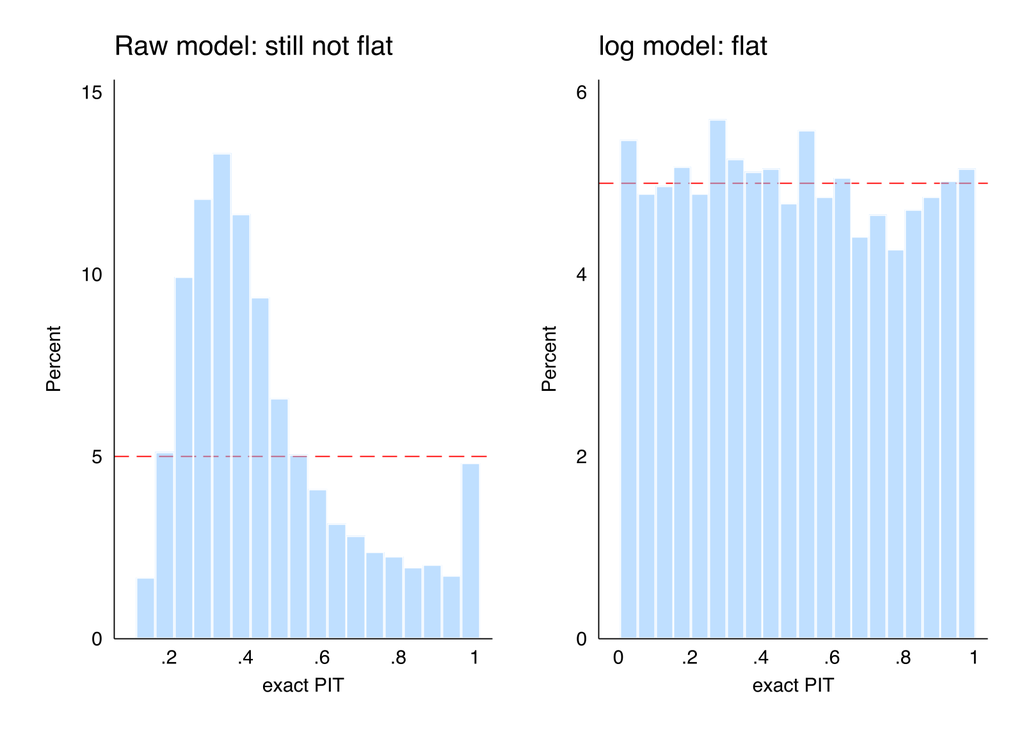

Exact deleted-residual PIT for the raw-days and log models. The verdict is identical to the plug-in PIT: the raw model is not flat, the log model is.

The exact PIT gives the **same verdict** and, with n ≈ 5700 and tiny leverage ($h_{ii}\approx p/n\approx 0.003$, so $t_{n-p-1}\approx$ normal), is numerically almost indistinguishable from the plug-in here. The raw model stays non-uniform because the main problem is the outcome **shape** not the plug-in approximation.

## 6. Checking the assumptions, in severity order

**Question**

Now, after all that, the textbook checks. The chapter orders them by the **severity of their consequences**:

1. correct **functional form** — biases coefficients;
2. **endogeneity** (predictors correlated with the error) — biases coefficients;
3. **independent errors** — affects standard errors;
4. **homoskedasticity** — affects standard errors;
5. **normal errors** — affects standard errors, least consequential.

Which of these actually matter for this LOS model?

**Hint**

Functional form: `acprplot`, `estat ovtest` (RESET), and AIC/BIC for the quadratic term. Endogeneity: there is no command — argue it with a DAG. Independence: cluster the SEs. Homoskedasticity: `rvfplot` and a robust-SE safety net. Normality: `qnorm`.

**Answer-1**

**1. Functional form.** Confirm the curvature modeled in `surv2md1`, and check the quadratic (`p6a1_fnxn`):

```stata
quietly regress lnlos i.cat1 c.surv2md1 i.dnr1 c.age i.sex
capture noisily acprplot surv2md1, lowess lsopts(lcolor(cranberry)) ///
    title("Component-plus-residual: surv2md1 (linear fit)")
qui graph export img/rhc_ff_acpr.png, replace width(1400)
```

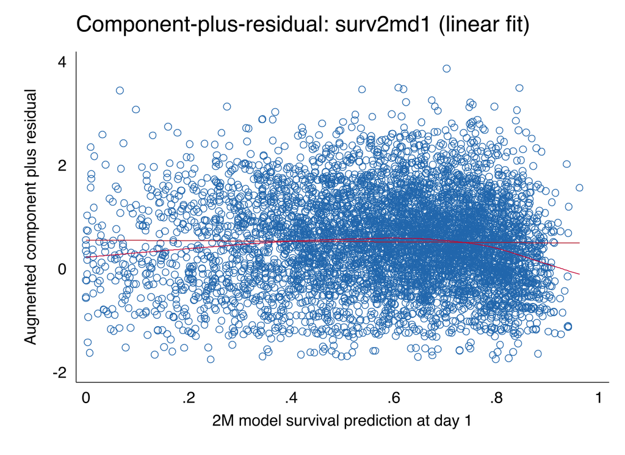

Component-plus-residual plot for predicted survival under a linear specification, showing curvature the lowess fit tracks.

```stata
estat ovtest
estimates store ff_linear
quietly regress lnlos i.cat1 c.surv2md1##c.surv2md1 i.dnr1 c.age i.sex
estimates store ff_quad
estimates stats ff_linear ff_quad
```

```
Ramsey RESET test for omitted variables
Omitted: Powers of fitted values of lnlos

H0: Model has no omitted variables

F(3, 5718) =   3.16
  Prob > F = 0.0237





Akaike's information criterion and Bayesian information criterion

-----------------------------------------------------------------------------
       Model |          N   ll(null)  ll(model)      df        AIC        BIC
-------------+---------------------------------------------------------------
   ff_linear |      5,734  -7706.042  -7419.037      13   14864.07   14950.58
     ff_quad |      5,734  -7706.042  -7382.425      14   14792.85   14886.01
-----------------------------------------------------------------------------
Note: BIC uses N = number of observations. See [R] IC note.
```

The Ramsey test suggests that there is an omitted variable or a non-linear relationship.

The AIC and BIC suggest that the model with the quadratic fits better than the one without.

**Answer-2**

**2. Endogeneity.** There is rarely any way to check this from the data. OLS forces the fitted residuals to be mechanically uncorrelated with the predictors, so an omitted baseline confounder hides inside the (biased) coefficients, not in a residual plot. Satisfying the assumption can only be argued by design and theory — supported by a DAG drawn before fitting.

There are some procedures for looking at how senstive your coefficients would be to an umeasured confounder (Oster/coefficient-stability sensitivity (`psacalc`)). If you can think of a variable that effectively randomizes an exposure in the model then you can use this as an instrument and test using a Hausman test (`ivregress 2sls` then `estat endog`).

As we pointed out in section 4: conditioning on in-hospital death by only analyzing survivors is endogenous **selection** — you cannot adjust your way out of endogeneity by adding a downstream variable.

**Answer-3**

**3. Independent errors.** (`p6a3_indep`) Think about potential clustering of data. For example, you could examine clustering within disease category (different diseases may have shared teams, protocols, pathways). Compare default and diagnosis-clustered SEs:

```stata
quietly regress lnlos c.surv2md1##c.surv2md1 i.dnr1 c.age i.sex i.cat1
estimates store se_default
quietly regress lnlos c.surv2md1##c.surv2md1 i.dnr1 c.age i.sex i.cat1, vce(cluster cat1)
estimates store se_cluster
estimates table se_default se_cluster, keep(1.dnr1 age) b(%6.3f) se ///
title("Default vs. diagnosis-clustered standard errors")
```

```
Default vs. diagnosis-clustered standard errors

----------------------------------
    Variable | se_de~t   se_cl~r
-------------+--------------------
        dnr1 |
        yes  |  -0.588    -0.588
             |   0.038     0.066
         age |  -0.003    -0.003
             |   0.001     0.001
----------------------------------
                      Legend: b/se
```

**Answer-4**

**4. Homoskedasticity.** (`p6a4_hetero`)